# Titanic Competition Tutorial (新人向け研修)

[figure not shown]

## 概要

- 性別や客室番号，チケット番号などからその人が生存したか死亡したかを出来るだけ精度良く予測できるようなモデルを作る
- データ分析コンテスト入門は，このデータセットでの分析から始めることが多い
- [kaggleのコンテストページ](https://www.kaggle.com/c/titanic/overview)

## 今日やること

- タイタニックのデータを元に機械学習モデルを作成して，予測を行うところまでやる
  - データ分析コンテストへの挑戦！
- 本当は，コンテストページ作ってみんなで精度を競うところまでやりたかったけど，用意の時間が取れませんでした．．．

## 本チュートリアルの想定読者と目的

### 想定読者

- **当部に配属された新人4人向け**
  - Pythonの簡単な公文(if文, for文)は知っている
  - pandas, numpyを触ったことがある(都度調べてもらえば知らなくても問題ないです)

### 目的

- データ分析のプログラムに触れ，実際に手を動かしてみてもらうこと
- 1人で簡単なデータ分析ができるようになってもらうこと
- 楽しんでもらうこと！

## データ分析の流れ

データ分析にはある程度決まった流れがあります．  
必ずしもこれ沿う必要はありませんが，私はこの流れに沿って行っています．  
本日はこの流れに沿って，４までを実際に行ってみる予定です．

### 1. データの把握

```
 - データの読み込み
 - データの行数・列数・csvファイル数の確認
 - データの型・欠損値の確認・全て同じ値をとる列はないか・独自のデータがあるかなど
```

### 2. ベースラインの作成

```
 - 簡単な前処理のみをしてベースとなる機械学習モデルを作る
 - 初めから全てやると分からなくなるので，雑に作った簡単な機械学習モデルをベースラインとして改良していく
```

### 3. EDA(探索的データ解析)

```
 - ベースラインの精度を改良するために，データを観察して様々な処理をかける
 - データ分析コンペの勝敗はここで決まると言って良い
 - 機械学習の知識を元にデータを処理することも重要だけど，個人的には取り組み続ける持久力と柔軟な発想力の方が重要だと思う
```

### 4. 精度確認

```
 - EDAで処理したデータでの精度を確認する
 - 精度が上がってれば意味があったと判断
 - 精度が変わらなければ意味なかったと判断
 - EDAと精度確認を繰り返して精度を上げていく(3と4の繰り返しがデータ分析の8割を占める)
```

### 5. モデルのチューニングとアンサンブル

```
 - 機械学習モデルにはそれぞれ自分で設定するパラメータがあるので，最適な値を探す(チューニング)
 - 複数のモデルを作ったなら組み合わせると精度が上がることが多い(アンサンブル)
```

## 1. データの把握

### 1.1. ライブラリのインポート

はじめに，データ分析で使用するライブラリをインポートしておきましょう！

```python
import boto3
import io
import pandas as pd
!pip install pandas_profiling
from IPython.display import clear_output
clear_output()

import pandas_profiling as pdp

import numpy as np
import pandas as pd
from pandas import DataFrame, Series
import matplotlib.pyplot as plt
import seaborn as sns

from sklearn.model_selection import train_test_split
from sklearn.metrics import accuracy_score
from sklearn.preprocessing import LabelEncoder
from sklearn.ensemble import RandomForestClassifier

import warnings
warnings.simplefilter('ignore', FutureWarning)
```

```python
%%html
<style>
table {float:left}
</style>
```

### 1.2. データの読み込み

ライブラリの準備ができたら，早速データを読み込みましょう．  
今回は，AWSのS3からデータを読み込みます．  
(細かいところはあまり意識せず，データを取ってきたんだな程度の理解で大丈夫です)

pandasのread_csv関数を使って,

- 分析する訓練データ：**train.csv**
- 予測を行いたいテストデータ：**test.csv**

を読み込みます.

(変数名に与えた**df**は、**DataFrame**を意味しています（変数名は何でも構いません）)

```python
def read_s3_csv(SRC_OBJECT_KEY_NAME, SRC_FILE_ENCODING="utf-8", SRC_BUCKET_NAME="dataanalytics-training-2021"):
    """
    S3のcsvファイルを読み込んで，pandasのdf型を返す

    Parameters
    ----------
    SRC_BUCKET_NAME : str
        S3のバケット名を指定する．
        今回は「dataanalytics-training-2021」で固定．
        その他のバケットはアクセスできないはず．
    SRC_OBJECT_KEY_NAME : str
        取得するcsvファイルのオブジェクト名を指定する．
    SRC_FILE_ENCODING：str
        csvファイルの文字エンコードの種類を指定する．

    Returns
    -------
   df : pandas.DataFrame
        csvファイルをデータフレームで読み込んだもの
    """

    # ファイルをロード
    s3 = boto3.resource('s3')
    src_obj = s3.Object(SRC_BUCKET_NAME, SRC_OBJECT_KEY_NAME)
    body_in = src_obj.get()['Body'].read().decode(SRC_FILE_ENCODING)

    # バッファを作成
    buffer_in = io.StringIO(body_in)

    # データフレーム化
    df = pd.read_csv(buffer_in)

    return df

train_df = read_s3_csv('train.csv')
train_df = train_df.drop("PassengerId", axis=1)
test_df  = read_s3_csv("test.csv")
test_df  = test_df.drop("PassengerId", axis=1)
```

### 1.3 データのサイズの確認

データをみる前に，データのサイズを確認しておきましょう.  
データのサイズによっては，モデルの作成方法などに工夫がいる場合がありますが，今回はデータ数が多くないので問題なさそうです．

```python
print('訓練データのデータ数は{}、変数は{}種類です。'.format(train_df.shape[0], train_df.shape[1]))
print('テストデータのデータ数は{}、変数は{}種類です'.format(test_df.shape[0], test_df.shape[1]))
```

```
訓練データのデータ数は891、変数は11種類です。
テストデータのデータ数は418、変数は10種類です
```

### 1.4 データの概観の確認

データのサイズを把握したら，早速データの概観を見てみましょう！

```python
train_df.head()
```

|  | Survived | Pclass | Name | Sex | Age | SibSp | Parch | Ticket | Fare | Cabin | Embarked |
| --- | --- | --- | --- | --- | --- | --- | --- | --- | --- | --- | --- |
| 0 | 0 | 3 | Braund, Mr. Owen Harris | male | 22.0 | 1 | 0 | A/5 21171 | 7.2500 | NaN | S |
| 1 | 1 | 1 | Cumings, Mrs. John Bradley (Florence Briggs Th... | female | 38.0 | 1 | 0 | PC 17599 | 71.2833 | C85 | C |
| 2 | 1 | 3 | Heikkinen, Miss. Laina | female | 26.0 | 0 | 0 | STON/O2. 3101282 | 7.9250 | NaN | S |
| 3 | 1 | 1 | Futrelle, Mrs. Jacques Heath (Lily May Peel) | female | 35.0 | 1 | 0 | 113803 | 53.1000 | C123 | S |
| 4 | 0 | 3 | Allen, Mr. William Henry | male | 35.0 | 0 | 0 | 373450 | 8.0500 | NaN | S |

```python
train_df.describe(include="all")
```

|  | Survived | Pclass | Name | Sex | Age | SibSp | Parch | Ticket | Fare | Cabin | Embarked |
| --- | --- | --- | --- | --- | --- | --- | --- | --- | --- | --- | --- |
| count | 891.000000 | 891.000000 | 891 | 891 | 714.000000 | 891.000000 | 891.000000 | 891 | 891.000000 | 204 | 889 |
| unique | NaN | NaN | 891 | 2 | NaN | NaN | NaN | 681 | NaN | 147 | 3 |
| top | NaN | NaN | Hegarty, Miss. Hanora "Nora" | male | NaN | NaN | NaN | CA. 2343 | NaN | C23 C25 C27 | S |
| freq | NaN | NaN | 1 | 577 | NaN | NaN | NaN | 7 | NaN | 4 | 644 |
| mean | 0.383838 | 2.308642 | NaN | NaN | 29.699118 | 0.523008 | 0.381594 | NaN | 32.204208 | NaN | NaN |
| std | 0.486592 | 0.836071 | NaN | NaN | 14.526497 | 1.102743 | 0.806057 | NaN | 49.693429 | NaN | NaN |
| min | 0.000000 | 1.000000 | NaN | NaN | 0.420000 | 0.000000 | 0.000000 | NaN | 0.000000 | NaN | NaN |
| 25% | 0.000000 | 2.000000 | NaN | NaN | 20.125000 | 0.000000 | 0.000000 | NaN | 7.910400 | NaN | NaN |
| 50% | 0.000000 | 3.000000 | NaN | NaN | 28.000000 | 0.000000 | 0.000000 | NaN | 14.454200 | NaN | NaN |
| 75% | 1.000000 | 3.000000 | NaN | NaN | 38.000000 | 1.000000 | 0.000000 | NaN | 31.000000 | NaN | NaN |
| max | 1.000000 | 3.000000 | NaN | NaN | 80.000000 | 8.000000 | 6.000000 | NaN | 512.329200 | NaN | NaN |

```python
test_df.head()
```

|  | Pclass | Name | Sex | Age | SibSp | Parch | Ticket | Fare | Cabin | Embarked |
| --- | --- | --- | --- | --- | --- | --- | --- | --- | --- | --- |
| 0 | 3 | Kelly, Mr. James | male | 34.5 | 0 | 0 | 330911 | 7.8292 | NaN | Q |
| 1 | 3 | Wilkes, Mrs. James (Ellen Needs) | female | 47.0 | 1 | 0 | 363272 | 7.0000 | NaN | S |
| 2 | 2 | Myles, Mr. Thomas Francis | male | 62.0 | 0 | 0 | 240276 | 9.6875 | NaN | Q |
| 3 | 3 | Wirz, Mr. Albert | male | 27.0 | 0 | 0 | 315154 | 8.6625 | NaN | S |
| 4 | 3 | Hirvonen, Mrs. Alexander (Helga E Lindqvist) | female | 22.0 | 1 | 1 | 3101298 | 12.2875 | NaN | S |

```python
test_df.describe(include="all")
```

|  | Pclass | Name | Sex | Age | SibSp | Parch | Ticket | Fare | Cabin | Embarked |
| --- | --- | --- | --- | --- | --- | --- | --- | --- | --- | --- |
| count | 418.000000 | 418 | 418 | 332.000000 | 418.000000 | 418.000000 | 418 | 417.000000 | 91 | 418 |
| unique | NaN | 418 | 2 | NaN | NaN | NaN | 363 | NaN | 76 | 3 |
| top | NaN | Collett, Mr. Sidney C Stuart | male | NaN | NaN | NaN | PC 17608 | NaN | B57 B59 B63 B66 | S |
| freq | NaN | 1 | 266 | NaN | NaN | NaN | 5 | NaN | 3 | 270 |
| mean | 2.265550 | NaN | NaN | 30.272590 | 0.447368 | 0.392344 | NaN | 35.627188 | NaN | NaN |
| std | 0.841838 | NaN | NaN | 14.181209 | 0.896760 | 0.981429 | NaN | 55.907576 | NaN | NaN |
| min | 1.000000 | NaN | NaN | 0.170000 | 0.000000 | 0.000000 | NaN | 0.000000 | NaN | NaN |
| 25% | 1.000000 | NaN | NaN | 21.000000 | 0.000000 | 0.000000 | NaN | 7.895800 | NaN | NaN |
| 50% | 3.000000 | NaN | NaN | 27.000000 | 0.000000 | 0.000000 | NaN | 14.454200 | NaN | NaN |
| 75% | 3.000000 | NaN | NaN | 39.000000 | 1.000000 | 0.000000 | NaN | 31.500000 | NaN | NaN |
| max | 3.000000 | NaN | NaN | 76.000000 | 8.000000 | 9.000000 | NaN | 512.329200 | NaN | NaN |

データが表示できたので，以下の手順でデータを把握していきます．

1. カラム名が何を指しているか把握する
2. 欠損値の有無を確認する
3. ターゲットの割合を確認する

### 1.4.1. カラム名の把握

[kaggle コンテストページ](https://www.kaggle.com/c/titanic/data)に説明があるので，その情報を書いておきます.

| 変数 | 定義 | 備考 |
| --- | --- | --- |
| Survived | 生存したかどうか | 0 = No, 1 = Yes |
| Pclass | チケットのクラス | 1 = 1st, 2 = 2nd, 3 = 3rd |
| Name | 名前 |  |
| Sex | 性別 |  |
| Age | 年齢 |  |
| SibSp | 乗船していた兄弟姉妹・配偶者の数 |  |
| Parch | 乗船していた親・子供の数 |  |
| Ticket | チケット番号 |  |
| Fare | チケット料金 |  |
| Cabin | キャビン番号 |  |
| embarked | 乗船した港 | C = Cherbourg, Q = Queenstown, S = Southampton |

### 1.4.2. 欠損値の確認

機械学習モデルは欠損値があると学習できない物が多いです．  
そのため，欠損値がある場合は何らかの処理をする必要があるので，どのカラムに欠損値が含まれるかを知っておく必要があります．

今回のデータだと，**Age**、**Fare**, **Cabin**、**Embarked**の値の一部が欠損していることがわかります．  
これらには後で対処することにしましょう．

```python
def display_isna(df, df_name):
    """
    データフレームの欠損値を確認する

    Parameters
    ----------
    df : pandas.DataFrame
        欠損値を表示するデータフレーム
    df_name :pandas.DataFrame
        インデックスに表示するデータフレーム名

    Returns
    -------
   df : pandas.DataFrame
        欠損値情報を持つデータフレーム
    """

    temp =  pd.DataFrame(df.isnull().sum()).T
    temp.index = [df_name + "の欠損値数"]
    return temp

display(display_isna(train_df, "train"))
display(display_isna(test_df, "test"))
```

|  | Survived | Pclass | Name | Sex | Age | SibSp | Parch | Ticket | Fare | Cabin | Embarked |
| --- | --- | --- | --- | --- | --- | --- | --- | --- | --- | --- | --- |
| trainの欠損値数 | 0 | 0 | 0 | 0 | 177 | 0 | 0 | 0 | 0 | 687 | 2 |

|  | Pclass | Name | Sex | Age | SibSp | Parch | Ticket | Fare | Cabin | Embarked |
| --- | --- | --- | --- | --- | --- | --- | --- | --- | --- | --- |
| testの欠損値数 | 0 | 0 | 0 | 86 | 0 | 0 | 0 | 1 | 327 | 0 |

### 1.4.3 ターゲットの割合の確認

データによってはターゲット(予測したい値)の分布が不均衡な場合があります．  
そのような場合は，不均衡データに対する対応をどのように行うかを検討する必要が出てきます．  
今回のデータは，**6:4程度**なので問題ない範囲です．

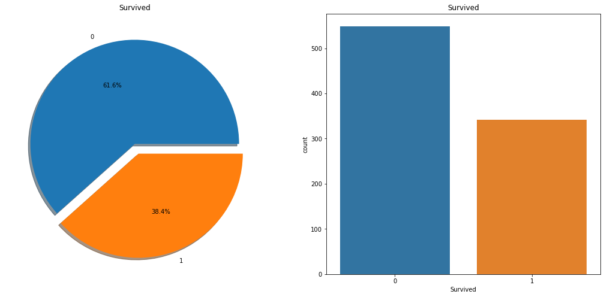

```python
f,ax=plt.subplots(1,2,figsize=(18,8))
train_df['Survived'].value_counts().plot.pie(explode=[0,0.1],autopct='%1.1f%%',ax=ax[0],shadow=True)
ax[0].set_title('Survived')
ax[0].set_ylabel('')
sns.countplot('Survived',data=train_df,ax=ax[1])
ax[1].set_title('Survived')
plt.show()
```

## 2. ベースラインの作成

データの内容が何となく分かったので，最低限のデータの前処理を行なった後，ベースラインとなる機械学習モデルを作成しましょう！

### 2.1. データの前処理

今回行うデータの前処理として以下2つを行います．

1. 欠損値の対処
2. カテゴリデータの対処

### 2.2.1. 欠損値の対処

欠損値を含むデータはそのままではモデル作成ができないため，何らかの対処をする必要があります．  
欠損値への対処に関しては，様々な方法がありますが，今回は最も簡単な**欠損値を含むデータを削除する**方法を取ろうと思います．  
(本来は，データを観察して扱うデータに最も適した手法を選ぶ必要があります)

#### 参考：欠損値への対処法の例

- 欠損値を含むデータを削除する
- 欠損値を平均値などの代表値で埋める
- 欠損値に絶対に取り得ない値を入れる(欠損値という情報を持たせる)
- 他の特徴量を元に機械学習モデルを作成し，欠損値を予測して埋める

```python
# 欠損値を含む行を削除
train_df = train_df.dropna()
test_df  = test_df.dropna()
```

### 2.2.2. カテゴリデータの対処

次にカテゴリデータの前処理を行います．  
一部のモデルを除いて，**機械学習はカテゴリデータを処理できない**ので，何らかの方法で数値データに置き換えてあげる必要があります．  
まずはどのカラムがカテゴリデータか確認しましょう．

```python
def display_dtypes(df, df_name):
    """
    データフレームの各カラムの型を確認する

    Parameters
    ----------
    df : pandas.DataFrame
        データフレーム
    df_name :pandas.DataFrame
        インデックスに表示するデータフレーム名

    Returns
    -------
   df : pandas.DataFrame
        各カラムの型情報を持つデータフレーム
    """

    temp =  pd.DataFrame(df.dtypes).T
    temp.index = [df_name + "の型情報"]
    return temp

display(display_dtypes(train_df, "train"))
display(display_dtypes(test_df, "test"))
```

|  | Survived | Pclass | Name | Sex | Age | SibSp | Parch | Ticket | Fare | Cabin | Embarked |
| --- | --- | --- | --- | --- | --- | --- | --- | --- | --- | --- | --- |
| trainの型情報 | int64 | int64 | object | object | float64 | int64 | int64 | object | float64 | object | object |

|  | Pclass | Name | Sex | Age | SibSp | Parch | Ticket | Fare | Cabin | Embarked |
| --- | --- | --- | --- | --- | --- | --- | --- | --- | --- | --- |
| testの型情報 | int64 | object | object | float64 | int64 | int64 | object | float64 | object | object |

object型が数値以外のデータ型なので，以下の5カラムがカテゴリデータだと分かります．  
次にこれらカラムに入っている実際のデータを見てみましょう．

- Name
- Sex
- Ticket
- Cabin
- Embarked

```python
display(train_df[["Name", "Sex", "Ticket", "Cabin", "Embarked"]].head())
display(test_df[["Name", "Sex", "Ticket", "Cabin", "Embarked"]].head())
```

|  | Name | Sex | Ticket | Cabin | Embarked |
| --- | --- | --- | --- | --- | --- |
| 1 | Cumings, Mrs. John Bradley (Florence Briggs Th... | female | PC 17599 | C85 | C |
| 3 | Futrelle, Mrs. Jacques Heath (Lily May Peel) | female | 113803 | C123 | S |
| 6 | McCarthy, Mr. Timothy J | male | 17463 | E46 | S |
| 10 | Sandstrom, Miss. Marguerite Rut | female | PP 9549 | G6 | S |
| 11 | Bonnell, Miss. Elizabeth | female | 113783 | C103 | S |

|  | Name | Sex | Ticket | Cabin | Embarked |
| --- | --- | --- | --- | --- | --- |
| 12 | Snyder, Mrs. John Pillsbury (Nelle Stevenson) | female | 21228 | B45 | S |
| 14 | Chaffee, Mrs. Herbert Fuller (Carrie Constance... | female | W.E.P. 5734 | E31 | S |
| 24 | Ryerson, Mrs. Arthur Larned (Emily Maria Borie) | female | PC 17608 | B57 B59 B63 B66 | C |
| 26 | Ostby, Miss. Helene Ragnhild | female | 113509 | B36 | C |
| 28 | Brady, Mr. John Bertram | male | 113054 | A21 | S |

上記のカラムは**取りえる値が決まっているかいないか**の2パターンに分けられます．  
取りえる値が決まっていないデータに関しては，処理が難しいため**今回は列ごと削除**します．

難しいというだけでやりようは色々あるので，興味があれば色々調べて試してみてください．  
(Nameなら，MrとかMrsを抽出して情報とする，Cabinなら初めの一文字部分を情報とするなど)

#### パターン1

- 取りえる値が決まっている
  - Sex
  - Embarked

#### パターン2

- 取りえる値が決まっていないもの
  - Name
  - Ticket
  - Cabin

```python
# 列ごと削除
drop_col = ["Name", "Ticket", "Cabin"]
train_df = train_df.drop(drop_col, axis=1)
test_df = test_df.drop(drop_col, axis=1)
```

#### ラベルエンコーディング

例) X,Y,Zというカテゴリデータを持つ場合

- X → 0
- Y → 1
- X → 2

というように同じカテゴリデータが同じ値を取るように数値に変換しています  
これによって，カテゴリデータではなく，数値データとしてX, Y, Zという3種類の違いを情報として機械学習モデルに与えることができます

参考: https://vector-ium.com/label-encoding-coding/

```python
# group_mise, group_itemに対してラベルエンコーディングする
cat_cols = ["Sex","Embarked"]
for c in cat_cols:
    le = LabelEncoder()
    le.fit(train_df[c])
    train_df[c] = le.transform(train_df[c])
    test_df[c] = le.transform(test_df[c])
```

### 2.3 ベースライン(モデル)の作成

これで最低限の前処理をできたので，機械学習モデルを作成していきます．  
今回はRandomForestという機械学習モデルを使用してみます．

### Random Forest

#### 概要

- 木モデルを使った機械学習モデル
- Decision Treeと呼ばれる単体では精度が良くないモデルを，複数集めることで単体のDecision Treeより精度の良いモデルを作る
- 複数のモデル毎に，学習に扱うデータと扱う特徴量を変えることでモデルのバリエーションを増やしている

#### 特徴

- データの前処理が楽(スケーリングなどが不要) -> 今回このモデルを選んだ理由
- モデルのパラメータ調整をしなくても精度が高く出やすい(初期値で十分精度が高い)
- モデルの内部のロジックが直感的で分かりやすい

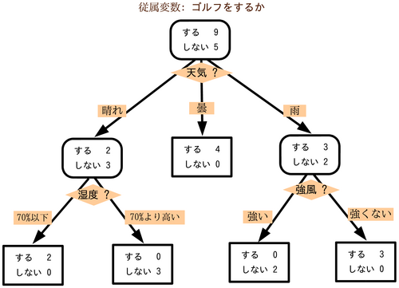

まずtrian_dfとtest_dfを**説明変数**と**目的変数**に分けましょう．

- **説明変数**：モデルの学習に使用する変数,今回の問題では**target以外の変数**
- **目的変数**：予測対象の変数,今回の問題では**target**

```python
# X：説明変数
# y：目的変数

y = train_df["Survived"]
X = train_df.drop("Survived", axis=1)
```

次に，**trainデータを学習用データと検証用データ**に分けましょう．  
学習に使ったデータで正解率を測ろうとすると，未知のデータに対する本当の精度が測れません．  
(学習用に使ったデータを見てモデルを作成しているため，学習用データはモデルにとって未知のデータではない)

(ひとまずそういうものなんだなという理解でも良いです)

```python
# X_train, y_train：学習用データ→7割
# X_valid, y_valid：検証用データ→3割
# random_stateの値は固定しましょう -> 再現性が確保されていることが用件なため

X_train, X_valid, y_train, y_valid = train_test_split(X, y, test_size=0.3, random_state=42)
```

これで準備が整ったので，**分けたデータを使ってモデルを学習しましょう**  
scikit-learnのモデルでは，

- **モデルを宣言**
- **モデル.fit ( 訓練データ(target除く), 正解データ(targetデータ) )**

で学習させることができます．

**scikit-learnで用意されているモデルならば，基本的にどのモデルでも同じように使うことができます**．  
(多くの機械学習モデルは既に何かしらのライブラリで実装されているので，基本的に自分でモデルをプログラミングする必要はないです)

```python
# モデルを学習しているので多少時間がかかります
# モデルを宣言(RandomForest) random_stateは固定しましょう
rfc = RandomForestClassifier(n_estimators=1000, random_state=42, n_jobs=-1)

# モデルの学習
rfc.fit(X_train, y_train)
```

```
RandomForestClassifier(n_estimators=1000, n_jobs=-1, random_state=42)
```

モデルが作成できたら，分けておいた検証用データを使用して正解率を確認してみましょう．

```python
# モデルの精度を確認

pred_valid = rfc.predict(X_valid)
print("valid score: ", accuracy_score(pred_valid, y_valid))

pred_train = rfc.predict(X_train)
print("\n※以下の訓練データにおける正解率は当てにしてはいけない")
print("train score: ", accuracy_score(pred_train, y_train))
```

```
valid score:  0.7454545454545455

※以下の訓練データにおける正解率は当てにしてはいけない
train score:  1.0
```

## Todo: RandomForest以外のモデルも試してみましょう

- sklearnのモデルであれば，全て同じように使用することができます

```python
# ----- ロジスティック回帰(LogisticRegression)
from sklearn.linear_model import LogisticRegression

linear = LogisticRegression()
linear.fit(X_train, y_train)
pred_valid = linear.predict(X_valid)
print("LogisticRegression valid score: ", accuracy_score(pred_valid, y_valid))
# -----

# ----- サポートベクターマシン(SVC)
from sklearn.svm import SVC

# write here!
# -----

# -----knn(KNeighborsClassifier)
from sklearn.neighbors import KNeighborsClassifier

# write here!
# -----
```

```
LogisticRegression valid score:  0.6909090909090909
```

## 3. EDA(探索的データ解析)

このセクションでは，データの加工(変更・追加・削除)することで，ベースラインのスコアを上げることが目的です．  
決まった手順などがあるわけではなく，データの探索をして仮説を立てながら，実際にデータを加工してスコアが上がるか試していきます．

ここでは，少ししか取りあげませんが，皆さんもいろいろ考えて取り組んでみてください.

まずは**データの概要**を見てみましょう．  
各データの散布図を書いてみます．  
(少し時間がかかります)

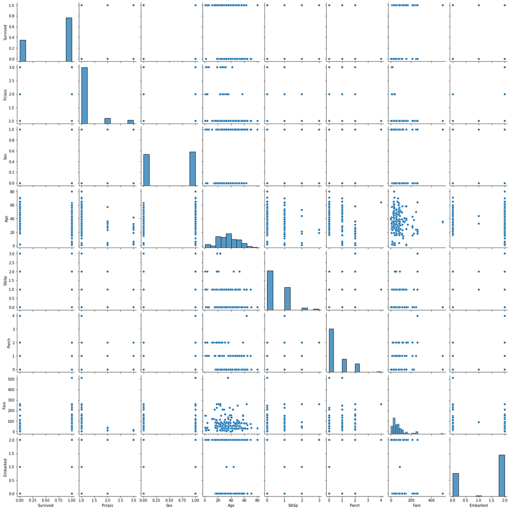

```python
sns.pairplot(train_df[[
    'Survived', 'Pclass', 'Sex', 'Age', 'SibSp', 'Parch','Fare', 'Embarked'
]])
```

この散布図を見ると，赤ちゃんは助かる確率が高いことが読み取れたりします．  
書いておいてあれですが，今回のデータはカテゴリデータが多く，散布図での可視化は向いていない気はします．．．

次に，**相関行列のヒートマップ**を表示して相関が強い特徴量の組みがないか確認しましょう．  
相関行列は各成分に対応する相関係数を並べた行列のことであり，値の大小に応じて色をつけたものをヒートマップと呼びます．  
この図を表示することによって，変数間の相関の強さを一目で把握することができます．

機械学習のモデルによっては,同じようなデータ(相関が強いデータ)が混ざっていると**多重共線性**という問題が生じる場合があります．  
そのため著しく相関の強い特徴量の組みがある場合は,**その特徴量のうち一つだけを残して他の変数を削除する**といった対策をすることがあります．

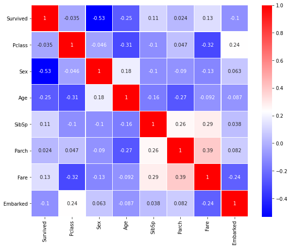

```python
sns.heatmap(train_df.corr(),annot=True,cmap='bwr',linewidths=0.2)
fig=plt.gcf()
fig.set_size_inches(10,8)
plt.show()
```

この図から、SibSpとParchの値に比較的強い正の相関があることがわかります．

- SibSp：**同乗していた兄弟姉妹・配偶者の数**
- Parch：**同乗していた親・子供の数**

なので，相関があることは直感的に理解できます．  
ここで**SibSpの値とParchの値の和をとって「同乗していた家族の人数」**という新しい変数を加えるアイデアが得られます．  
SibSpとParchという不自然な分類で二つの変数に分割してあるよりも「同乗していた家族の人数」という変数の方が自然な可能性があるためです．

他にもPclassとFareの値に比較的強い負の相関が見られます．  
この相関から，Pclassの値が小さいほどチケットのグレードが高いことが予想できます．

**SibSpの値とParchの値の和をとって「同乗していた家族の人数」という新しい変数を加える**というアイデアで，精度向上するか試してみましょう！

```python
# SibSpの値とParchの値の和をとって「同乗していた家族の人数」を列に追加
train_df["Family"] = train_df["SibSp"] + train_df["Parch"]
test_df["Family"]  = test_df["SibSp"] + test_df["Parch"]

# SibSpとParchの情報を削除
drop_col = ["SibSp", "Parch"]
train_df = train_df.drop(drop_col, axis=1)
test_df = test_df.drop(drop_col, axis=1)

# 説明変数と目的変数に分ける
y = train_df["Survived"]
X = train_df.drop("Survived", axis=1)

# 学習データと検証データに分ける
X_train, X_valid, y_train, y_valid = train_test_split(X, y, test_size=0.3, random_state=42)
```

```python
# モデルを学習しているので多少時間がかかります
# モデルを宣言(RandomForest) random_stateは固定しましょう
rfc = RandomForestClassifier(n_estimators=1000, random_state=42, n_jobs=-1)

# モデルの学習
rfc.fit(X_train, y_train)
```

```
RandomForestClassifier(n_estimators=1000, n_jobs=-1, random_state=42)
```

```python
# モデルの精度を確認

pred_valid = rfc.predict(X_valid)
print("valid score: ", accuracy_score(pred_valid, y_valid))
```

```
valid score:  0.7090909090909091
```

```python
# テストデータに対して予測値を求める
pred = rfc.predict(test_df)
print(pred)
```

[output not shown]

## 残りの時間で精度を上げてみよう！

- 何から始めれば良いかわからない
  - 以下の参考情報を元に，まずはデータを観察して気づきを探すのが良いと思います！
- やりたいことは見つかったけど，実装方法がわからない
  - 遠慮なく聞いてください！

### 思いつくもの

- 欠損値の対処法を変えてみる
- カテゴリ変数への対処法を変えてみる
- モデルを変えてみる
- 説明変数を増減させてみる
- ...

## 以下は参考情報

```python
# # pandas profilling
# train_profile = pdp.ProfileReport(train)
# train_profile
```

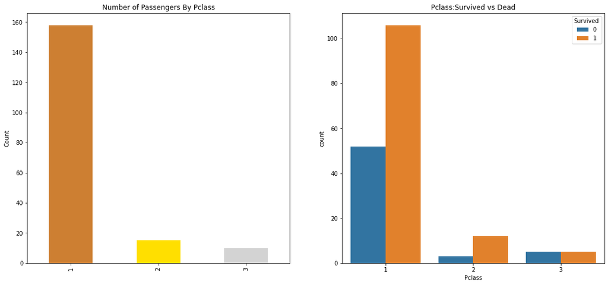

```python
# Pclassごとの生存率
f,ax=plt.subplots(1,2,figsize=(18,8))
train_df['Pclass'].value_counts().plot.bar(color=['#CD7F32','#FFDF00','#D3D3D3'],ax=ax[0])
ax[0].set_title('Number of Passengers By Pclass')
ax[0].set_ylabel('Count')
sns.countplot('Pclass',hue='Survived',data=train_df,ax=ax[1])
ax[1].set_title('Pclass:Survived vs Dead')
plt.show()
```

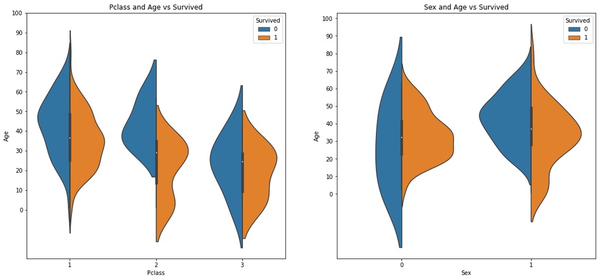

```python
# 年齢ごとの生存率

f,ax=plt.subplots(1,2,figsize=(18,8))
sns.violinplot("Pclass","Age", hue="Survived", data=train_df,split=True,ax=ax[0])
ax[0].set_title('Pclass and Age vs Survived')
ax[0].set_yticks(range(0,110,10))
sns.violinplot("Sex","Age", hue="Survived", data=train_df,split=True,ax=ax[1])
ax[1].set_title('Sex and Age vs Survived')
ax[1].set_yticks(range(0,110,10))
plt.show()
```